# NBA Win Predictions by C. Andrew Byrd IV

# Introduction

I have recently been reading “Mathletics” by Wayne Winston (http://waynewinston.com/wordpress/?page_id=13). It’s a neat book where this sport enthusiast and math professor walks the reader through how to calculate most any statistic for baseball, basketball, and football. I found his chapters on basketball and the NBA very fun to read. I also wanted to test his thoughts on how to predict wins for NBA teams using only information from the box score. He issues the assertion that you can create a wins model by looking at about 8 different variables regarding everything from effectiveness in the team’s shooting to the other team’s effectiveness in getting to the free throw line.

To create the model, Winston compares a team’s abilities against their opponents (i.e. The team’s EFG% vs the opponent’s EFG%). This is done with EFG, TTP, Rebrate, and FTR by just take the differences between the team’s statistics and their opponents. I’ve created these fields below to be studied within this project.

I’ve outlined all details of the data in the “NBA Data Info”" file.

# Variable Analysis

```
## [1] 1014   18
```

```
##  [1] "X"            "Team"         "year"         "W.L."
##  [5] "Conference"   "MadePlayoffs" "EFG"          "Opp_EFG"
##  [9] "TTP"          "DTTP"         "ORebRate"     "DRebRate"
## [13] "FTR"          "OFTR"         "EFG_diff"     "TTP_diff"
## [17] "RebRate_diff" "FTR_diff"
```

```
## 'data.frame':    1014 obs. of  18 variables:
##  $ X           : int  1 2 3 4 5 6 7 8 9 10 ...
##  $ Team        : Factor w/ 39 levels "Atlanta Hawks",..: 1 1 1 1 1 1 1 1 1 1 ...
##  $ year        : int  1981 1985 1990 1992 2000 2001 2002 2003 2004 2005 ...
##  $ W.L.        : num  0.378 0.415 0.5 0.463 0.341 0.305 0.402 0.427 0.341 0.159 ...
##  $ Conference  : Factor w/ 2 levels "East","West": 1 1 1 1 1 1 1 1 1 1 ...
##  $ MadePlayoffs: Factor w/ 2 levels "No","Yes": 1 1 1 1 1 1 1 1 1 1 ...
##  $ EFG         : num  0.48 0.489 0.496 0.481 0.46 ...
##  $ Opp_EFG     : num  0.498 0.485 0.509 0.497 0.481 ...
##  $ TTP         : num  0.266 0.247 0.219 0.222 0.246 ...
##  $ DTTP        : num  0.27 0.246 0.226 0.221 0.2 ...
##  $ ORebRate    : num  0.336 0.316 0.353 0.323 0.301 ...
##  $ DRebRate    : num  0.642 0.623 0.625 0.654 0.668 ...
##  $ FTR         : num  0.293 0.25 0.277 0.203 0.217 ...
##  $ OFTR        : num  0.295 0.249 0.254 0.209 0.196 ...
##  $ EFG_diff    : num  -0.01755 0.00356 -0.01314 -0.0158 -0.02156 ...
##  $ TTP_diff    : num  -0.003762 0.001072 -0.006916 0.000317 0.04618 ...
##  $ RebRate_diff: num  -0.306 -0.307 -0.272 -0.331 -0.367 ...
##  $ FTR_diff    : num  -0.0017 0.00152 0.02303 -0.00643 0.02137 ...
```

```
##  [1] "Atlanta Hawks"
##  [2] "Boston Celtics"
##  [3] "Brooklyn Nets"
##  [4] "Charlotte Bobcats"
##  [5] "Charlotte Hornets"
##  [6] "Chicago Bulls"
##  [7] "Cleveland Cavaliers"
##  [8] "Dallas Mavericks"
##  [9] "Denver Nuggets"
## [10] "Detroit Pistons"
## [11] "Golden State Warriors"
## [12] "Houston Rockets"
## [13] "Indiana Pacers"
## [14] "Kansas City Kings"
## [15] "Los Angeles Clippers"
```

[output cut: 24 more lines]

```
## [1] "No"  "Yes"
```

```
## [1] "East" "West"
```

```
##        X                           Team          year
##  Min.   :   1.0   Atlanta Hawks      : 37   Min.   :1980
##  1st Qu.: 254.2   Boston Celtics     : 37   1st Qu.:1990
##  Median : 507.5   Chicago Bulls      : 37   Median :1999
##  Mean   : 507.5   Cleveland Cavaliers: 37   Mean   :1999
##  3rd Qu.: 760.8   Denver Nuggets     : 37   3rd Qu.:2008
##  Max.   :1014.0   Detroit Pistons    : 37   Max.   :2016
##                   (Other)            :792
##       W.L.        Conference MadePlayoffs      EFG
##  Min.   :0.1060   East:508   No :439      Min.   :0.4242
##  1st Qu.:0.3780   West:506   Yes:575      1st Qu.:0.4760
##  Median :0.5120                           Median :0.4891
##  Mean   :0.5000                           Mean   :0.4894
##  3rd Qu.:0.6175                           3rd Qu.:0.5012
##  Max.   :0.8890                           Max.   :0.5616
##
##     Opp_EFG            TTP              DTTP           ORebRate
##  Min.   :0.4226   Min.   :0.1919   Min.   :0.1864   Min.   :0.1808
##  1st Qu.:0.4770   1st Qu.:0.2253   1st Qu.:0.2251   1st Qu.:0.2549
##  Median :0.4900   Median :0.2380   Median :0.2372   Median :0.2813
##  Mean   :0.4892   Mean   :0.2379   Mean   :0.2379   Mean   :0.2813
##  3rd Qu.:0.5022   3rd Qu.:0.2500   3rd Qu.:0.2497   3rd Qu.:0.3078
##  Max.   :0.5398   Max.   :0.3089   Max.   :0.2998   Max.   :0.3767
##
##     DRebRate           FTR              OFTR           EFG_diff
##  Min.   :0.5790   Min.   :0.1456   Min.   :0.1580   Min.   :-0.0752389
##  1st Qu.:0.6454   1st Qu.:0.2155   1st Qu.:0.2143   1st Qu.:-0.0176898
##  Median :0.6658   Median :0.2341   Median :0.2338   Median :-0.0005880
##  Mean   :0.6671   Mean   :0.2356   Mean   :0.2357   Mean   : 0.0001453
##  3rd Qu.:0.6896   3rd Qu.:0.2554   3rd Qu.:0.2574   3rd Qu.: 0.0195345
##  Max.   :0.7510   Max.   :0.3344   Max.   :0.3466   Max.   : 0.0828751
##
##     TTP_diff           RebRate_diff        FTR_diff
##  Min.   :-7.189e-02   Min.   :-0.5500   Min.   :-0.1375773
##  1st Qu.:-1.521e-02   1st Qu.:-0.4332   1st Qu.:-0.0235662
##  Median :-3.452e-04   Median :-0.3848   Median : 0.0009545
##  Mean   : 5.791e-05   Mean   :-0.3857   Mean   :-0.0001373
##  3rd Qu.: 1.518e-02   3rd Qu.:-0.3357   3rd Qu.: 0.0244218
##  Max.   : 6.364e-02   Max.   :-0.2376   Max.   : 0.0967220
##
```

### What is the structure of your dataset?

Each observation has variables associated with advanced statistics of basketball performance. Outside of the category fields (i.e. Making the playoffs and a team’s conference), the variables have a pairing of how well the team performs in this area and how well the team’s opponents fair in the same area. This includes variables like:

Effective Field Goal % (EFG) & Opponent Effective Field Goal % (Opp_EFG) Turnovers / Possession (TTP) & Turnovers Caused / Possession (DTTP) Offensive Rebound Rate (ORebRate) & Defensive Rebound Rate (DRebRate) Free Throw Rate (FTR) & Opponent’s Free Throw Rate (OFTR)

Since there is such a pairing among 8 (4 pairings) of my variables, I’ve also included the difference to better display how a team performs against opponents for that skill (i.e. Effective Field Goal % Difference).

Some of my categorical variables include whether a team made the playoffs (post season tournament reserved for top half of teams) and which conference they reside (East or West).

### What is/are the main feature(s) of interest in your dataset?

The main features of the data set are Winning % and the 4 pairing team vs opponent difference variables (EFG, TTP, RebRate, and FTR) as I want expand upon Wayne Winston’s work (He only examined 1 year, using Excel) of predicting winning % from the difference variables.

### What other features in the dataset do you think will help support your investigation into your feature(s) of interest?

I think it will also be helpful to look at the individual variables (non difference pairs) and the “MadePlayoffs” variable in terms of predicting win percentage. I believe the “MadePlayoffs” variable will be very helpful when graphed to show direction of variable effectiveness (i.e. Using a scatter plot with colored dots based on if the team made the playoffs will show which teams are doing better).

### Did you create any new variables from existing variables in the dataset?

I created the difference pair variables. It’s the method Winston determined was the based relationship for measuring wins. The remainder were created by scraping data from Basketball Reference website (Outlined in separate file).

### Of the features you investigated, were there any unusual distributions? Did you perform any operations on the data to tidy, adjust, or change the form of the data? If so, why did you do this?

It’s very interesting that the mean for the W.L. is .500. I say that because it seems very ideal. It’s not always the case but I can also see that we should have “normal” like graphs as most of the means and medians are very close in values. I was able to scrape the data in the current form (it just needed a few clean up scripts and merging).

# Variable Plots

The graphs below offer a quick histogram for each variable. I also broke out each variable within “facet_wrap” to show any difference for playoff teams and non-playoff teams. I thought this would help determine if there are basketball benefits to the variable as going to the playoffs is seen as being success.

## W/L%

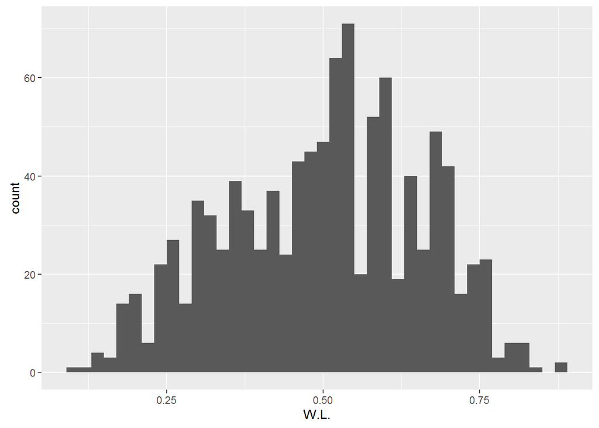

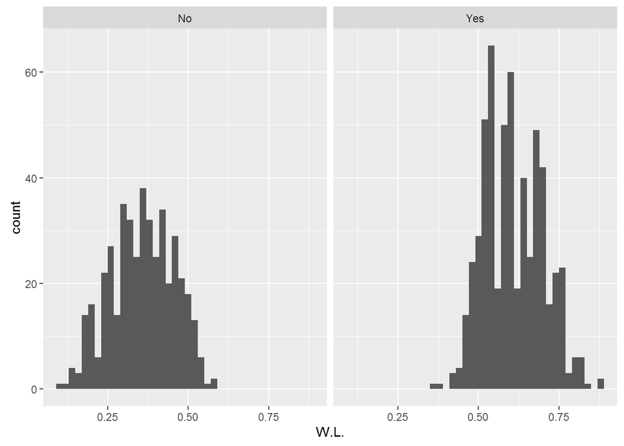

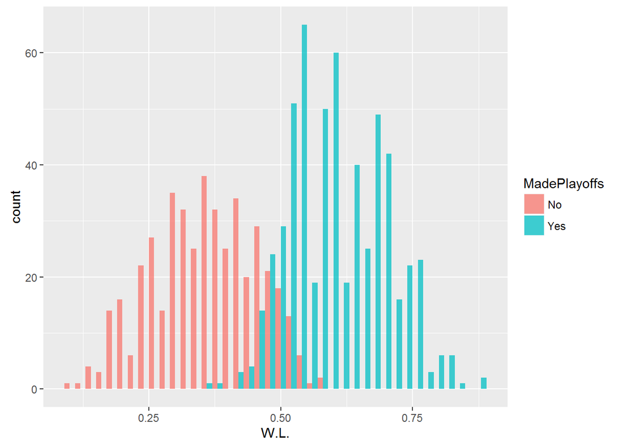

```
## nba$MadePlayoffs: No
##    Min. 1st Qu.  Median    Mean 3rd Qu.    Max.
##  0.1060  0.2930  0.3660  0.3576  0.4295  0.5850
## --------------------------------------------------------
## nba$MadePlayoffs: Yes
##    Min. 1st Qu.  Median    Mean 3rd Qu.    Max.
##  0.3660  0.5370  0.6100  0.6088  0.6730  0.8890
```

The W.L.% has a somewhat normal distribution. It’s also obvious that teams with a higher winning percentage are more likely to be in the playoffs.

## EFG (Effective Field Goal Percentage)

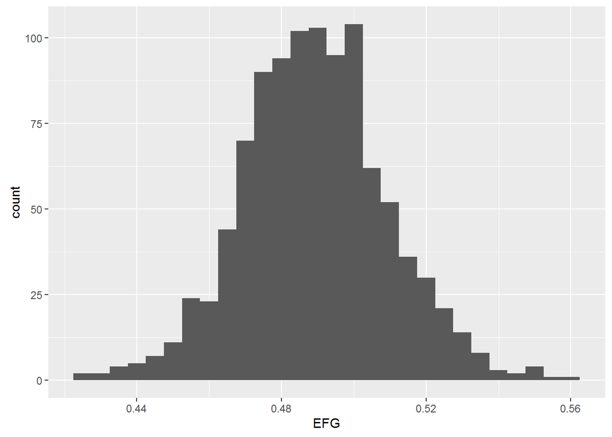

```
##    Min. 1st Qu.  Median    Mean 3rd Qu.    Max.
##  0.4242  0.4760  0.4891  0.4894  0.5012  0.5616
```

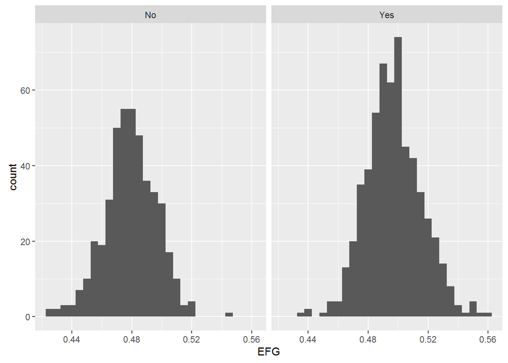

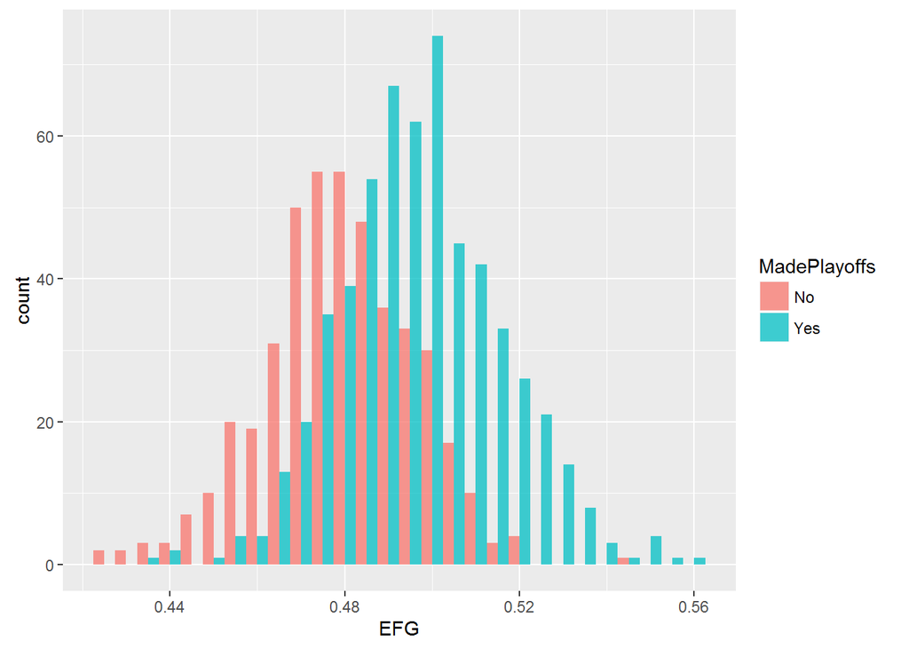

```
## nba$MadePlayoffs: No
##    Min. 1st Qu.  Median    Mean 3rd Qu.    Max.
##  0.4242  0.4693  0.4792  0.4792  0.4911  0.5451
## --------------------------------------------------------
## nba$MadePlayoffs: Yes
##    Min. 1st Qu.  Median    Mean 3rd Qu.    Max.
##  0.4355  0.4854  0.4965  0.4971  0.5086  0.5616
```

The 2nd graph kind of make me think better shooting teams are more likely to be in the playoffs. The range seems kind of small at .42 to .56. I figured some teams would be worse.

## Opp_EFG (Opps Effective Field Goal Percentage)

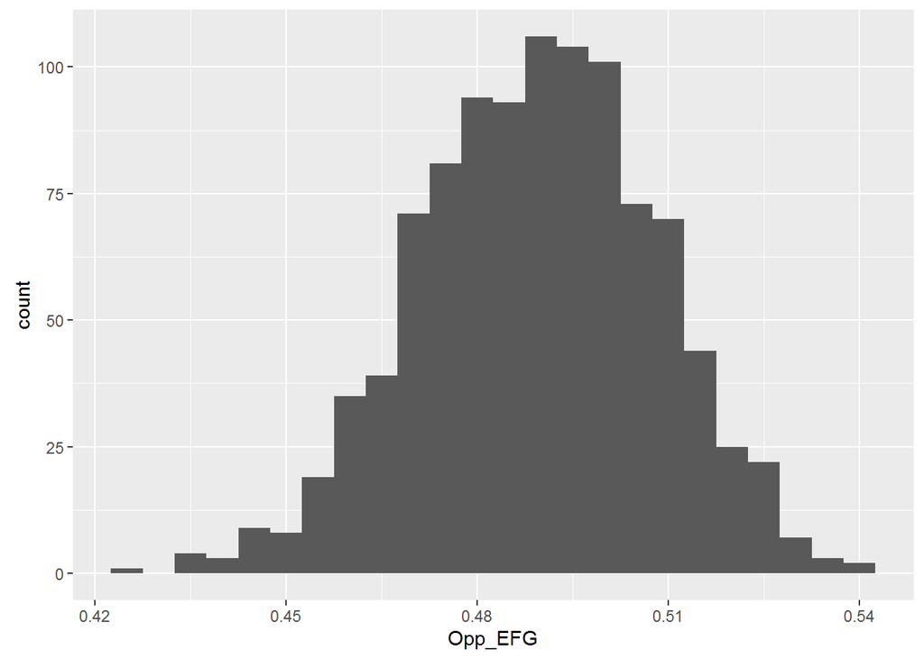

```
##    Min. 1st Qu.  Median    Mean 3rd Qu.    Max.
##  0.4226  0.4770  0.4900  0.4892  0.5022  0.5398
```

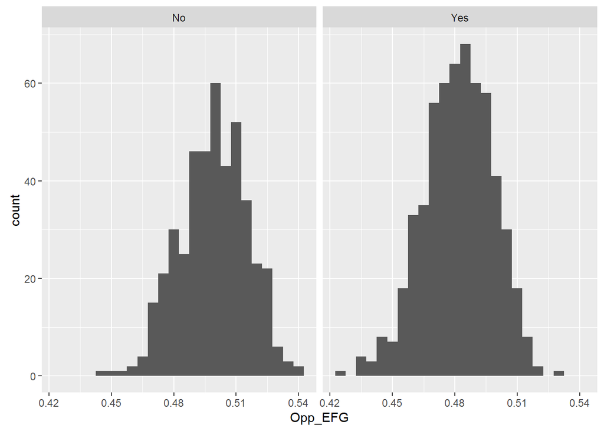

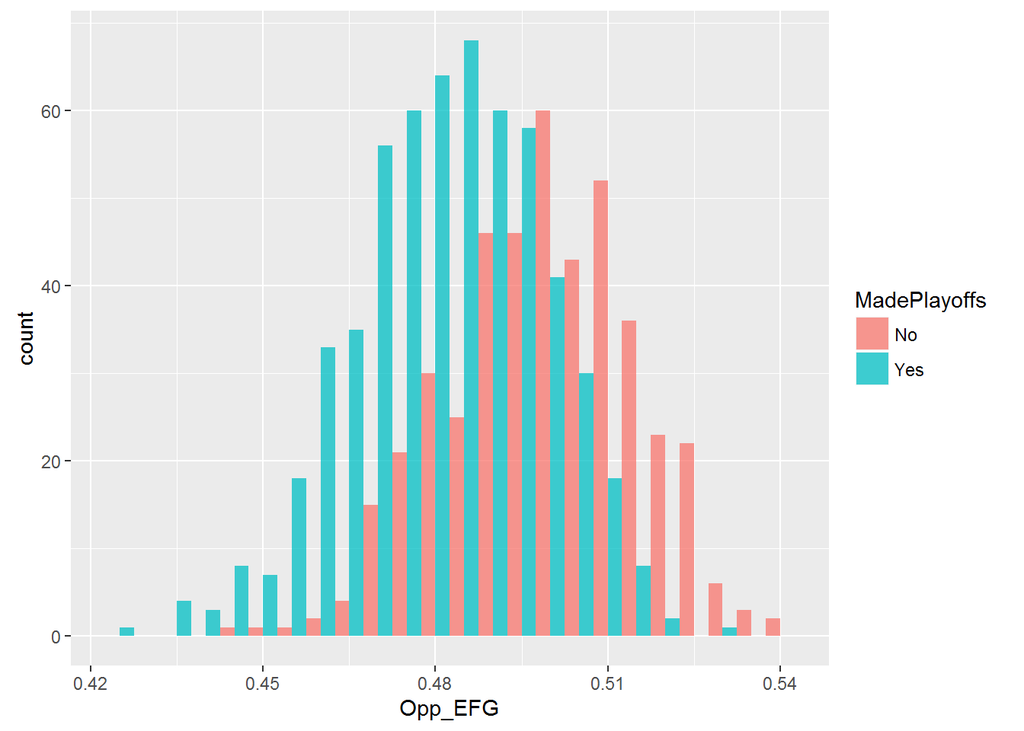

```
## nba$MadePlayoffs: No
##    Min. 1st Qu.  Median    Mean 3rd Qu.    Max.
##  0.4453  0.4888  0.4995  0.4991  0.5109  0.5398
## --------------------------------------------------------
## nba$MadePlayoffs: Yes
##    Min. 1st Qu.  Median    Mean 3rd Qu.    Max.
##  0.4226  0.4707  0.4824  0.4816  0.4930  0.5278
```

I think the 2nd graph paints a similar picture to before. This time it leads us to think that better defenses will get in the playoffs. Again, the range is quite small (smaller than EFG) at .42 to .54.

## EFG_diff

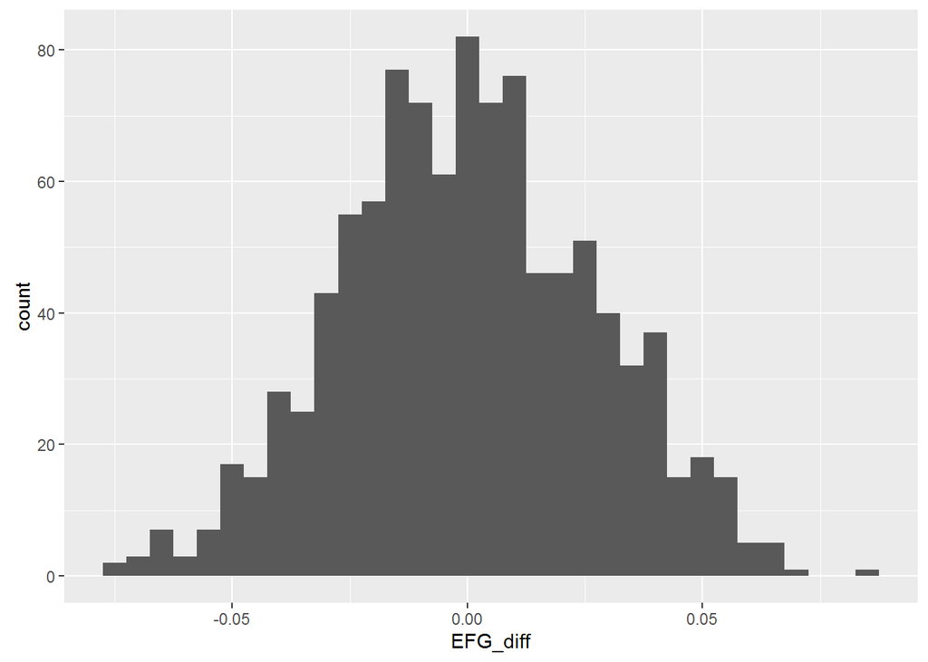

```
##       Min.    1st Qu.     Median       Mean    3rd Qu.       Max.
## -0.0752400 -0.0176900 -0.0005880  0.0001453  0.0195300  0.0828800
```

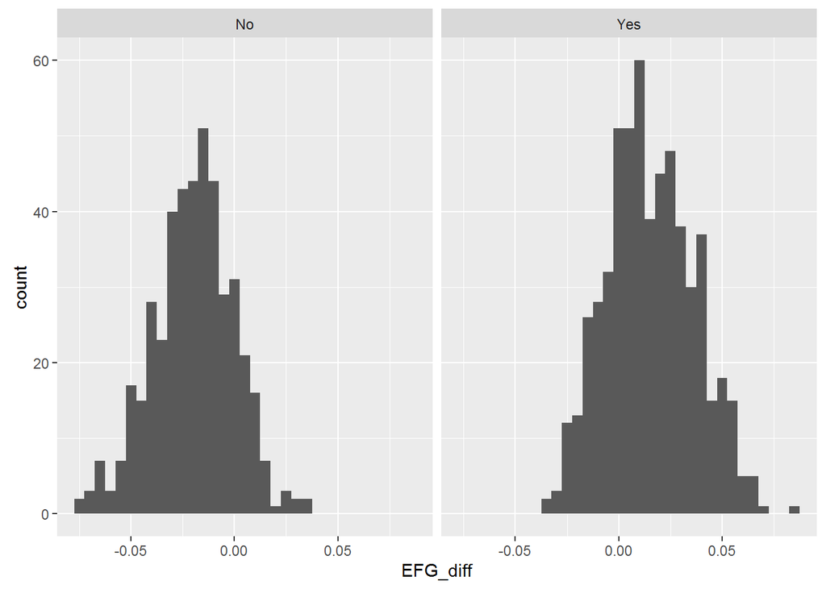

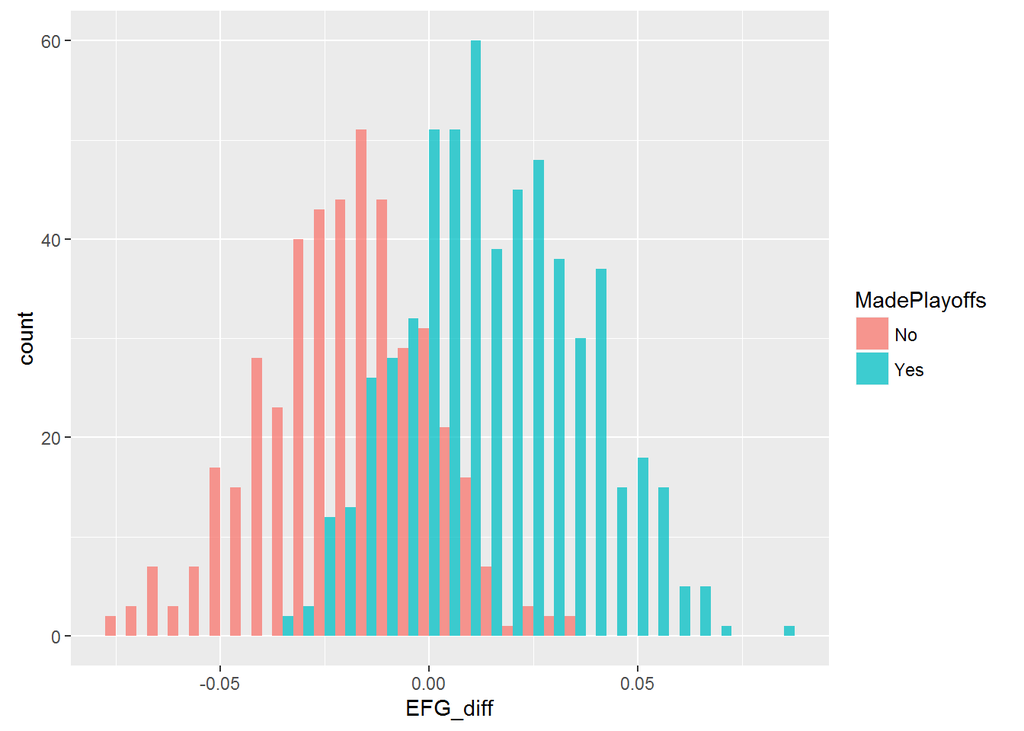

```
## nba$MadePlayoffs: No
##      Min.   1st Qu.    Median      Mean   3rd Qu.      Max.
## -0.075240 -0.031850 -0.019440 -0.019930 -0.007318  0.036250
## --------------------------------------------------------
## nba$MadePlayoffs: Yes
##       Min.    1st Qu.     Median       Mean    3rd Qu.       Max.
## -3.740e-02 -7.460e-06  1.382e-02  1.547e-02  3.061e-02  8.288e-02
```

It’s great to see the normal distribution as that should help with the linear model. There does seem to be a big effect between playoff and non-playoff teams if you look at the graph.

## TTP (Team Turnovers / Possession)

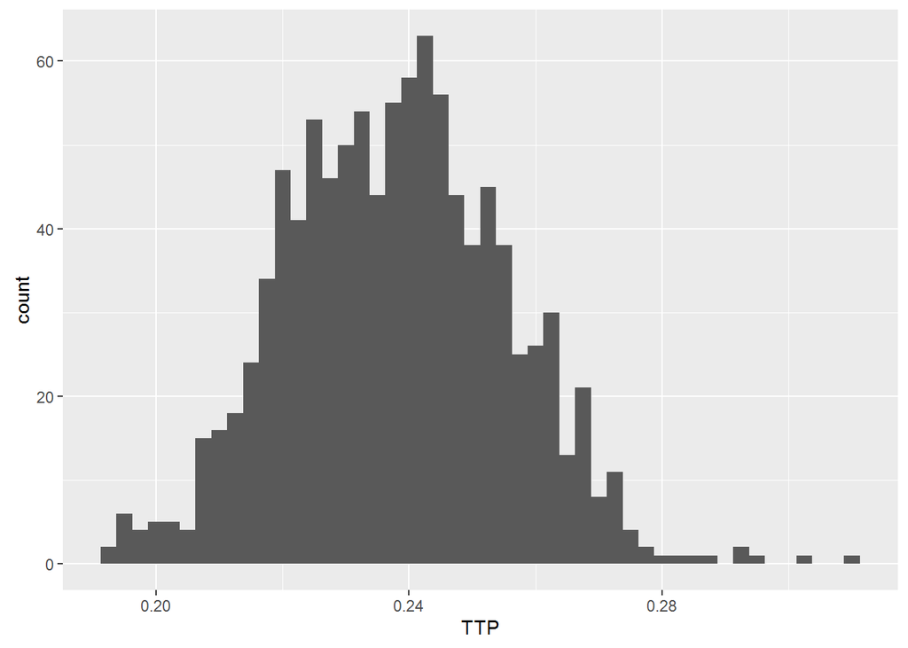

```
##    Min. 1st Qu.  Median    Mean 3rd Qu.    Max.
##  0.1919  0.2253  0.2380  0.2379  0.2500  0.3089
```

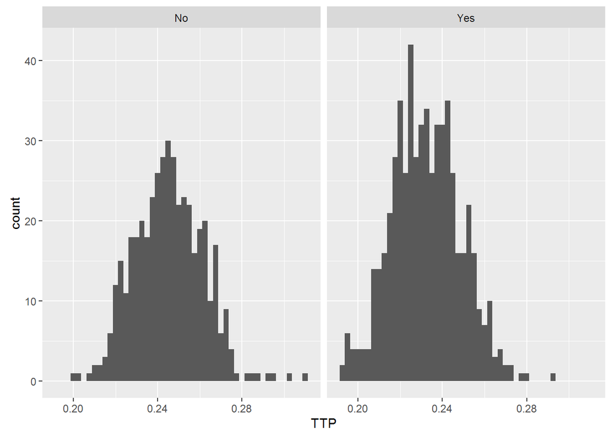

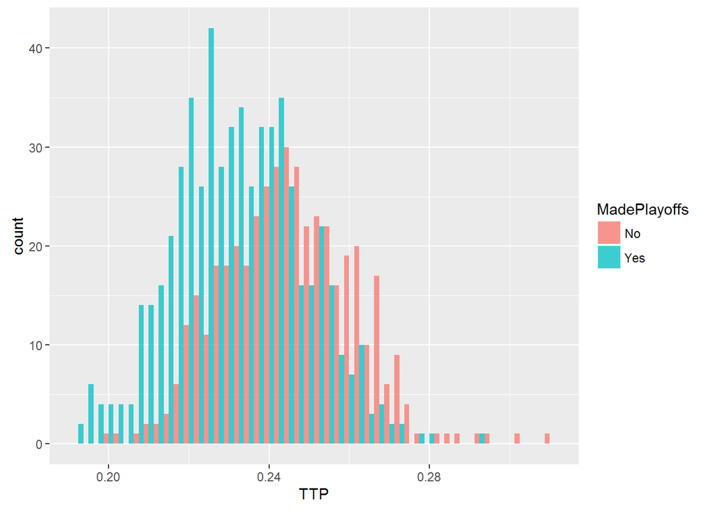

```
## nba$MadePlayoffs: No
##    Min. 1st Qu.  Median    Mean 3rd Qu.    Max.
##  0.2010  0.2336  0.2451  0.2453  0.2562  0.3089
## --------------------------------------------------------
## nba$MadePlayoffs: Yes
##    Min. 1st Qu.  Median    Mean 3rd Qu.    Max.
##  0.1919  0.2207  0.2319  0.2323  0.2432  0.2929
```

Teams should expect to turn the ball over between 1/5 to 1/3 of their possessions. The difference doesn’t seem to be as big between playoff and non-playoff teams as compared to EFG.

## DTTP (Defensive (Caused) Turnovers / Possession)

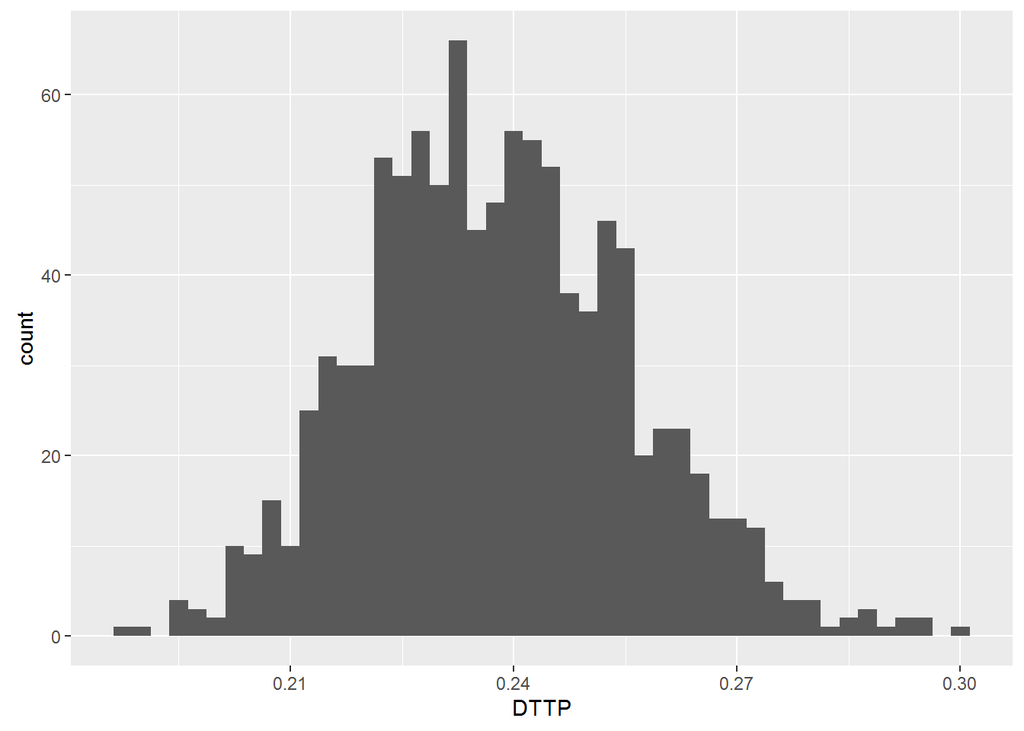

```
##    Min. 1st Qu.  Median    Mean 3rd Qu.    Max.
##  0.1864  0.2251  0.2372  0.2379  0.2497  0.2998
```

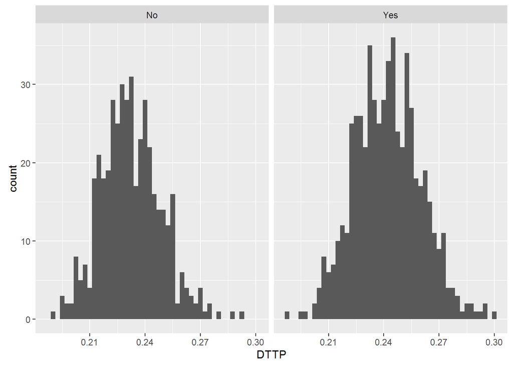

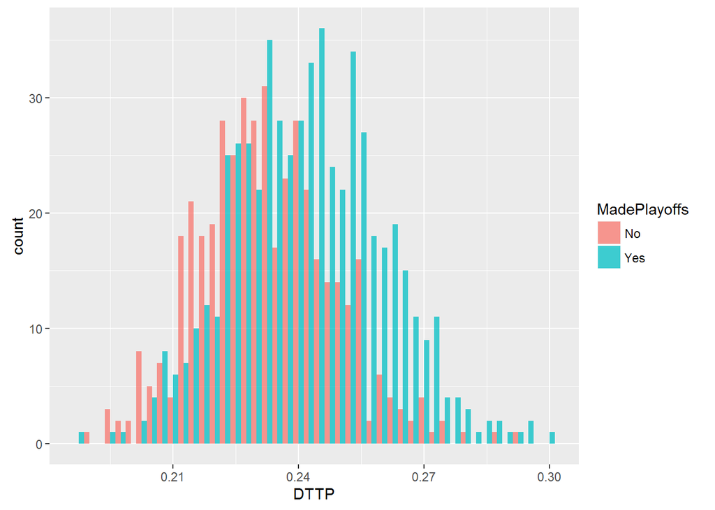

```
## nba$MadePlayoffs: No
##    Min. 1st Qu.  Median    Mean 3rd Qu.    Max.
##  0.1896  0.2214  0.2313  0.2323  0.2423  0.2928
## --------------------------------------------------------
## nba$MadePlayoffs: Yes
##    Min. 1st Qu.  Median    Mean 3rd Qu.    Max.
##  0.1864  0.2293  0.2424  0.2421  0.2540  0.2998
```

## TTP_diff

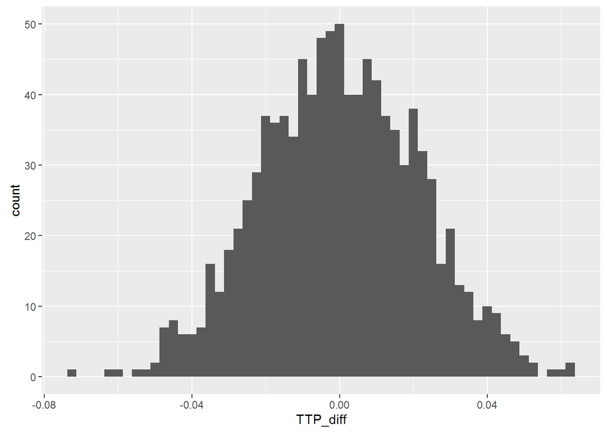

```
##       Min.    1st Qu.     Median       Mean    3rd Qu.       Max.
## -7.189e-02 -1.521e-02 -3.452e-04  5.791e-05  1.518e-02  6.364e-02
```

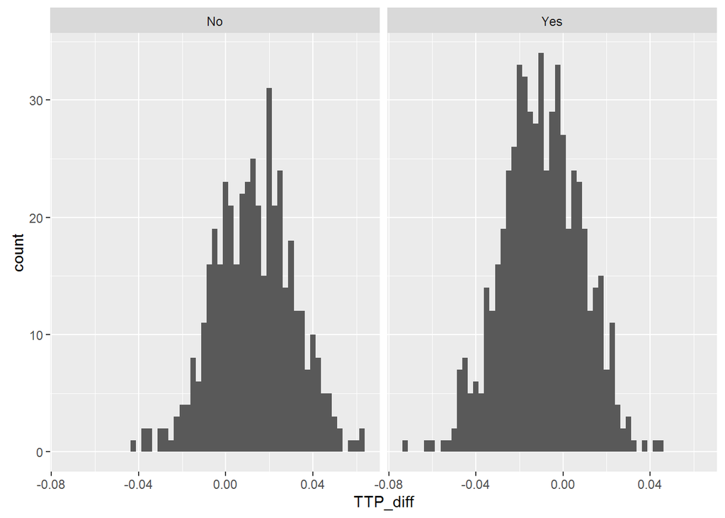

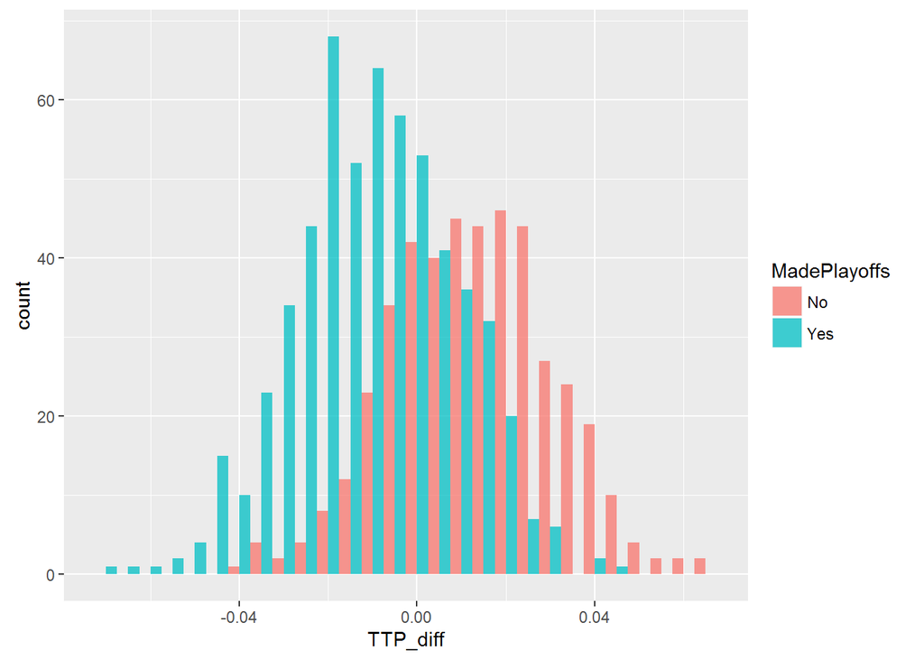

```
## nba$MadePlayoffs: No
##       Min.    1st Qu.     Median       Mean    3rd Qu.       Max.
## -0.0417100  0.0005568  0.0130100  0.0129800  0.0247700  0.0636400
## --------------------------------------------------------
## nba$MadePlayoffs: Yes
##      Min.   1st Qu.    Median      Mean   3rd Qu.      Max.
## -0.071890 -0.021550 -0.010360 -0.009807  0.002650  0.044160
```

Another very “normalish” variable to use for linear model building.

## ORebRate (Offensive Rebound Rate)

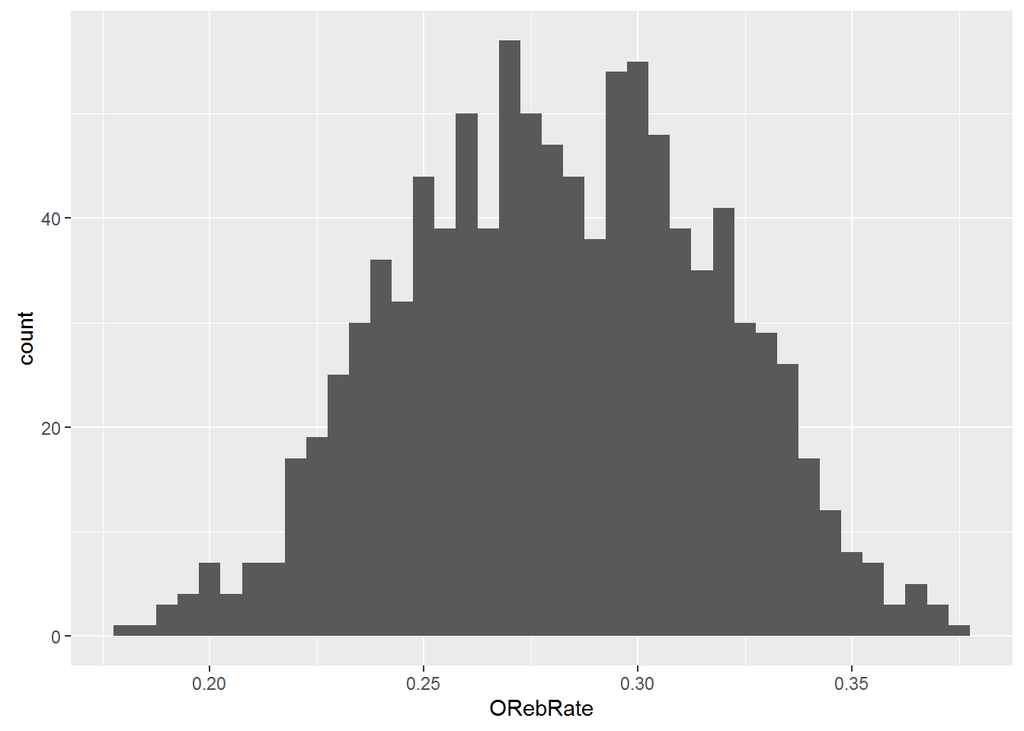

```
##    Min. 1st Qu.  Median    Mean 3rd Qu.    Max.
##  0.1808  0.2549  0.2813  0.2813  0.3078  0.3767
```

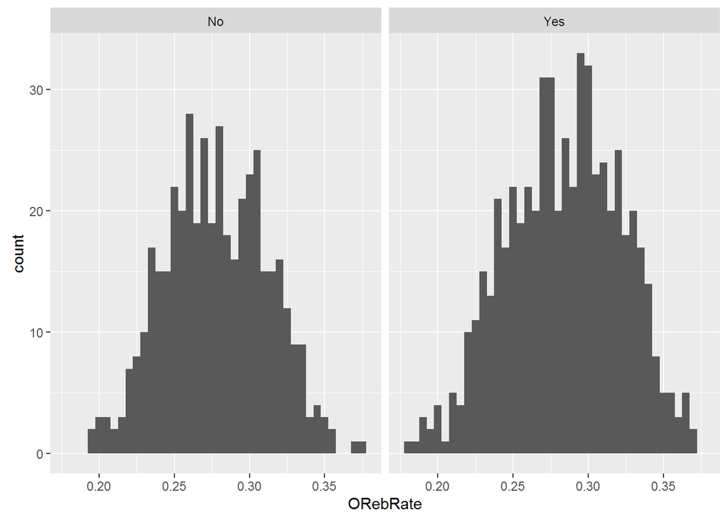

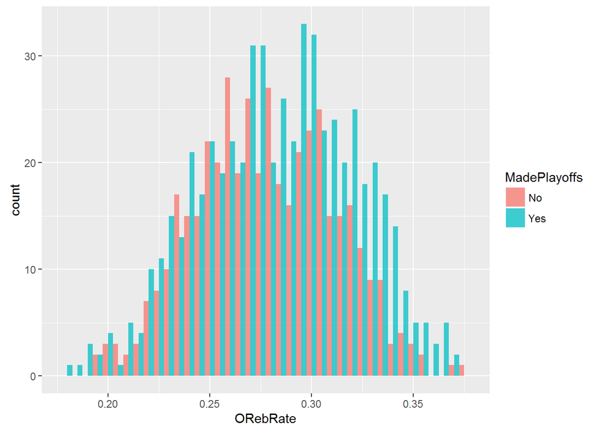

```
## nba$MadePlayoffs: No
##    Min. 1st Qu.  Median    Mean 3rd Qu.    Max.
##  0.1940  0.2534  0.2778  0.2780  0.3039  0.3767
## --------------------------------------------------------
## nba$MadePlayoffs: Yes
##    Min. 1st Qu.  Median    Mean 3rd Qu.    Max.
##  0.1808  0.2567  0.2851  0.2839  0.3118  0.3693
```

Teams will expect to grab their off 18% to 38% of their offensive rebounds. Visually, I’m not sure I can tell a difference between playoff and non-playoff teams for this variable.

## DRebRate (Defensive Rebound Rate)

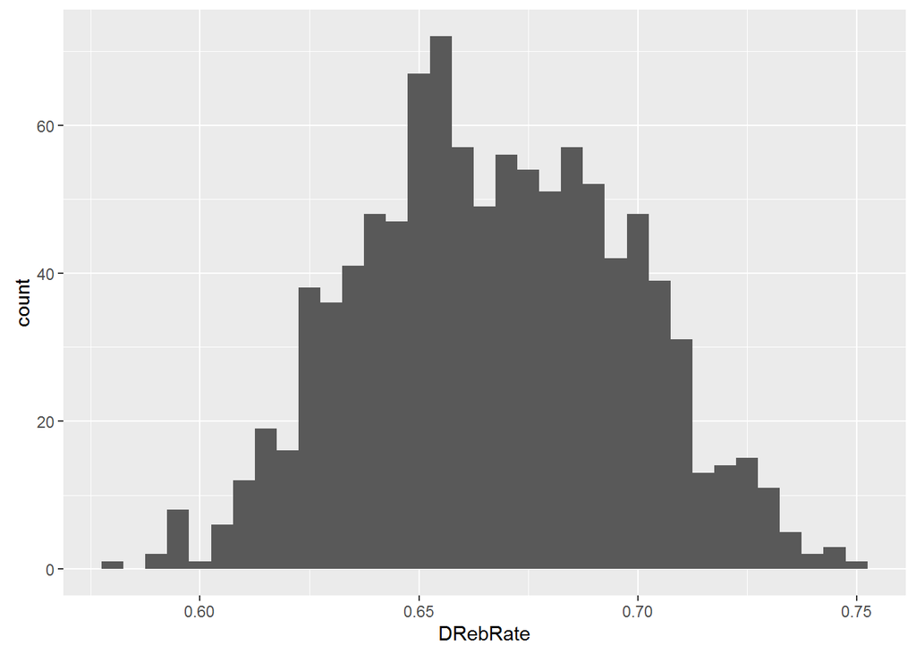

```
##    Min. 1st Qu.  Median    Mean 3rd Qu.    Max.
##  0.5790  0.6454  0.6658  0.6671  0.6896  0.7510
```

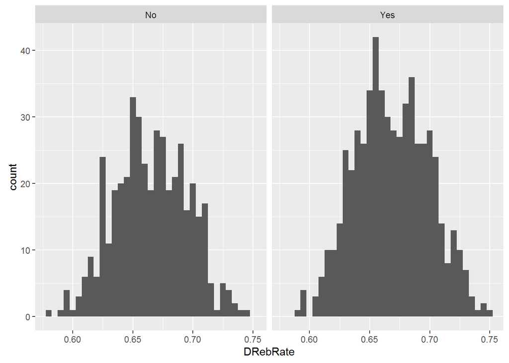

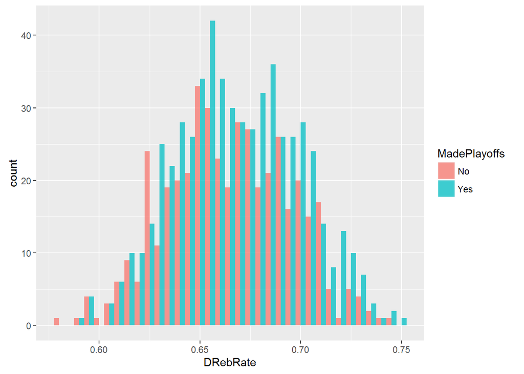

```
## nba$MadePlayoffs: No
##    Min. 1st Qu.  Median    Mean 3rd Qu.    Max.
##  0.5790  0.6433  0.6646  0.6649  0.6878  0.7462
## --------------------------------------------------------
## nba$MadePlayoffs: Yes
##    Min. 1st Qu.  Median    Mean 3rd Qu.    Max.
##  0.5889  0.6468  0.6668  0.6687  0.6908  0.7510
```

## RebRate_diff

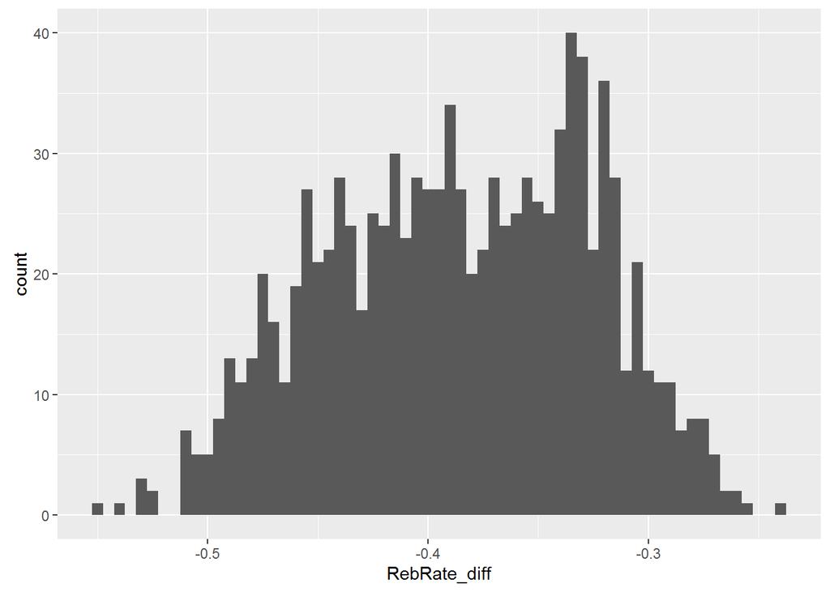

```
##    Min. 1st Qu.  Median    Mean 3rd Qu.    Max.
## -0.5500 -0.4332 -0.3848 -0.3857 -0.3357 -0.2376
```

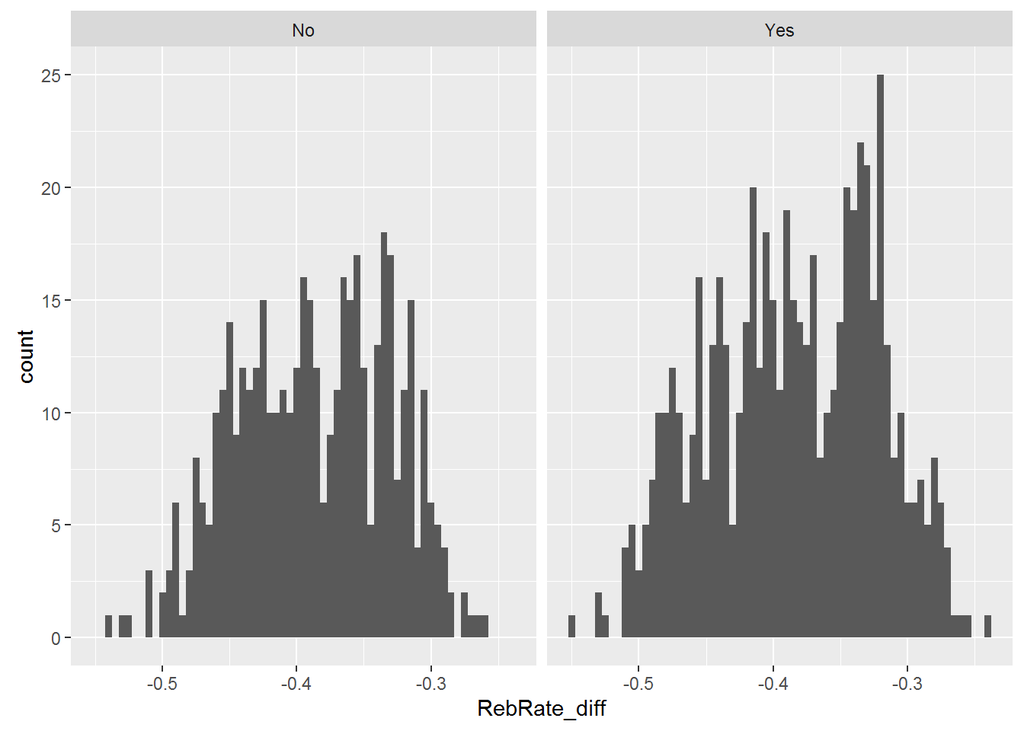

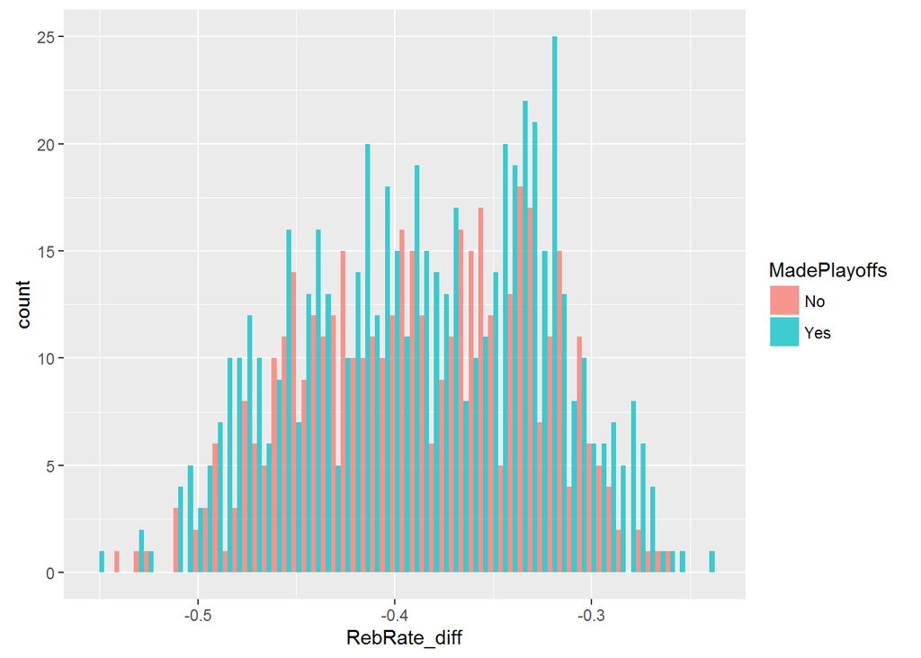

```
## nba$MadePlayoffs: No
##    Min. 1st Qu.  Median    Mean 3rd Qu.    Max.
## -0.5397 -0.4306 -0.3862 -0.3869 -0.3389 -0.2587
## --------------------------------------------------------
## nba$MadePlayoffs: Yes
##    Min. 1st Qu.  Median    Mean 3rd Qu.    Max.
## -0.5500 -0.4337 -0.3827 -0.3848 -0.3336 -0.2376
```

This variable is much less normal. I almost want to say it has a bi-modal shape to it.